# PART-1:

# Univariate analysis:

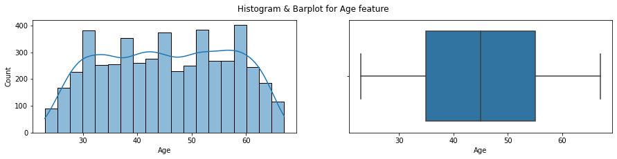

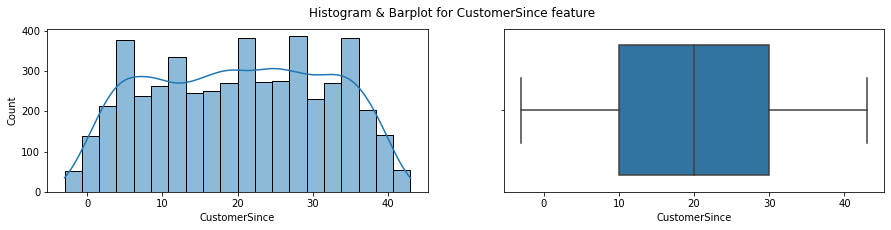

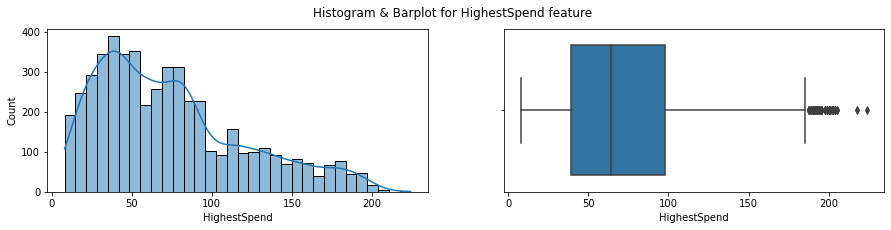

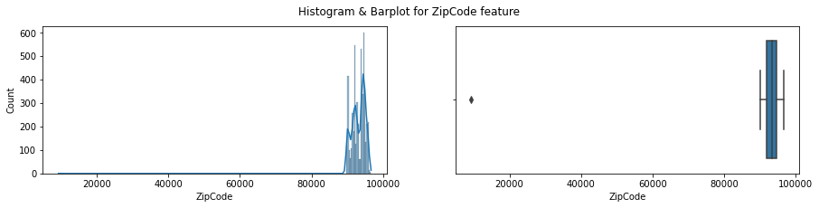

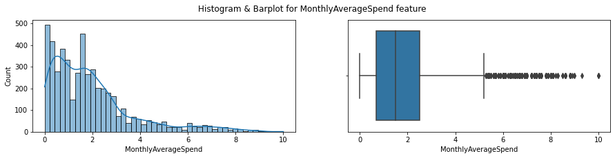

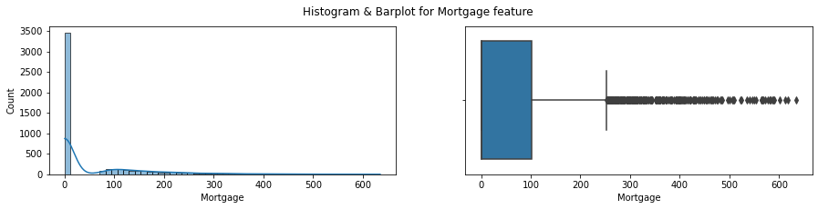

```python
num_cols = df.select_dtypes(exclude='category').columns.to_list()
for i in num_cols:
    fig,ax=plt.subplots(nrows=1, ncols=2, figsize=(15,3))
    plt.suptitle("Histogram & Barplot for {} feature".format(i), ha='center')
    sns.histplot(data=df,x=i,ax=ax[0],fill=True, kde=True)
    sns.boxplot(data=df,x=i,ax=ax[1])
```

# Observations:

. MonthlyAverageSpend - values are distributed around 0 to 10, and most values are spreaded between 1 & 3. with right skewn. outliers are available around 6 values.

. ZipCode - i believe, we should consider this are contineous rather than the discreate values.

. HighestSpend - values are between 0 and 200. with right skew.

. Age - is a continuous variables, and most customer are between the age 35 to 55.

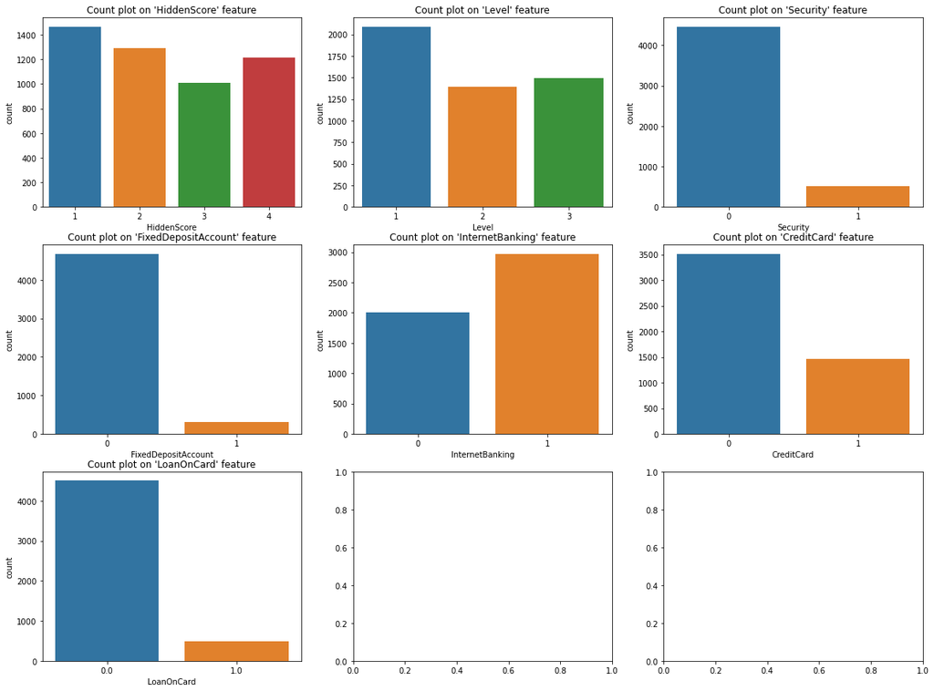

```python
cat=df.select_dtypes(include='category').columns.to_list()
fig, ax= plt.subplots(nrows=3, ncols=3, figsize=(20,15),)
ax=ax.flatten()
j=0
for i in cat:
    ax[j].set_title("Count plot on '{}' feature".format(i))
    sns.countplot(data=df, x=i, ax=ax[j])
    j=j+1
```

# Observations:

Hidden score - is distribured between 1, 2, 3 & 4.

Level - is distributed between 1,2 & 3

Security - value is 0 or 1. most cases it is 0

FixedDeposit - 0 or 1 for yes or no, mostly it is 0

InternetBanking - 0 or 1 for yes or no, mostly customer has Internetbanking.

CreditCard - 0 or 1 for yes or no. most customers doesn't have Creditcard

LoanOnCard - 0 or 1 for yes or no. most customer doesn't have loan on card.